# Modeling and prediction for movies

## Setup

### Load packages

```r
library(data.table)
library(purrr)
library(dplyr)
library(tidyr)
```

```r
library(ggplot2)
```

### Load data

Make sure your data and R Markdown files are in the same directory. When loaded your data file will be called `movies`. Delete this note when before you submit your work.

```r
load("movies")
```

## Part 1: Data

```r
movies1 <- data.table(movies)
```

## Part 2: Research question

can the genre or the runtime of a movie help us to predict its popularity?

firs some exploratory data for the runtime and the popularity with the IMDB raiting score

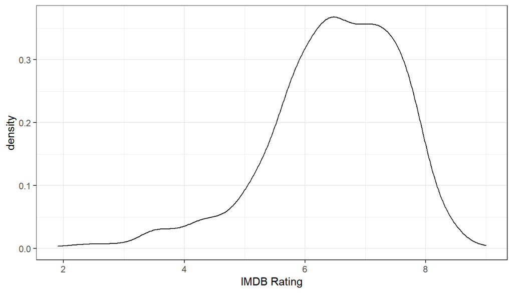

```r
ggplot(movies1, aes(imdb_rating)) + geom_density(kernel = "gaussian") +
 theme_bw() + xlab("IMDB Rating")
```

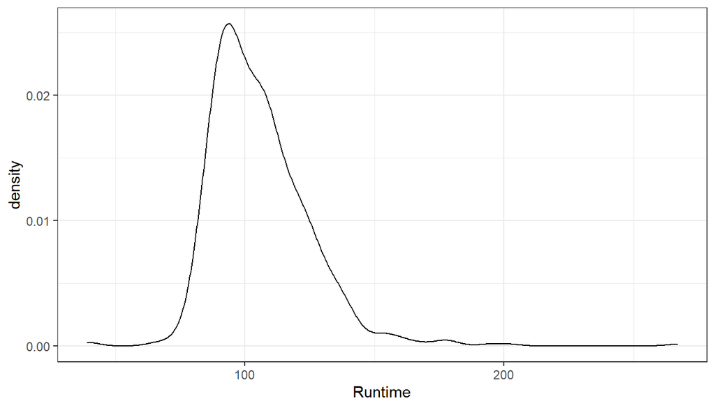

```r
 ggplot(movies1, aes(runtime)) + geom_density(kernel = "gaussian") +
 theme_bw() + xlab("Runtime")
```

now we will see the average runtime and IMDB rating by genre

```r
movies1[ , lapply(.SD, mean, na.rm = T), .SDcols = c("imdb_rating", "runtime"), by = "genre"]
```

```
##                         genre imdb_rating   runtime
##  1:                     Drama    6.673443 110.80328
##  2:                    Comedy    5.744828  96.94253
##  3:                    Horror    5.760870  92.13043
##  4:               Documentary    7.648077  96.49020
##  5:        Action & Adventure    5.970769 103.80000
##  6: Art House & International    6.614286 102.14286
##  7: Musical & Performing Arts    7.300000 113.75000
##  8:        Mystery & Suspense    6.479661 110.16949
##  9:                 Animation    5.900000  87.22222
## 10: Science Fiction & Fantasy    5.755556 101.00000
## 11:                     Other    6.631250 111.18750
```

We see some diference between the average by genre

## Part 3: Exploratory data analysis

for EDA first i show you the distribution of the runtime and the IMDB rating by genre

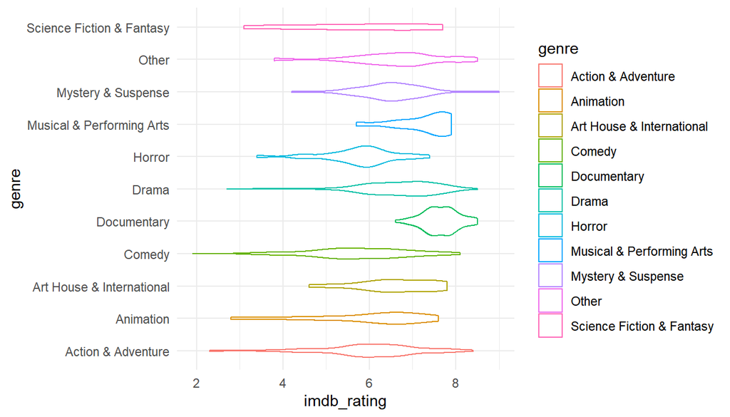

```r
ggplot(movies1, aes(imdb_rating, genre, col = genre)) +
 geom_violin(scale = "area" ) +
  theme_minimal()
```

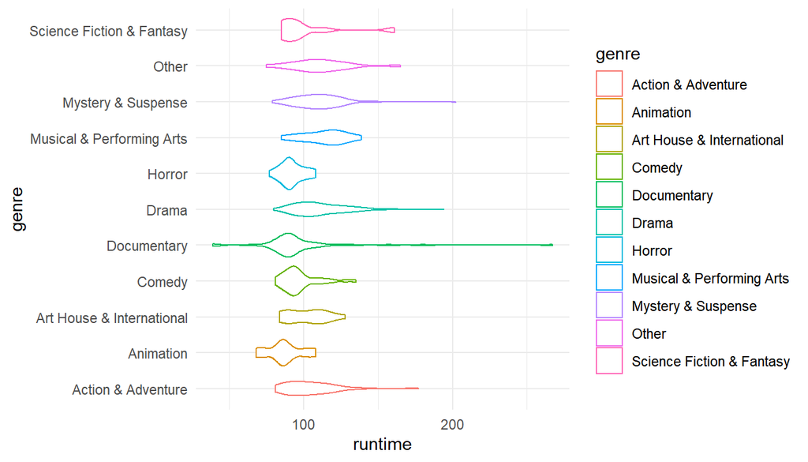

```r
ggplot(movies1, aes(runtime, genre, col = genre)) +
 geom_violin(scale = "area" ) +
  theme_minimal()
```

for the IMDB rating the genre with the highest average are the documentary and the comedy movies are the lowest IMDB rating on average, the runtime of documentary movies its the most variation between the genres and the animation are the genre with less runtime on average

now see the interation between the factors

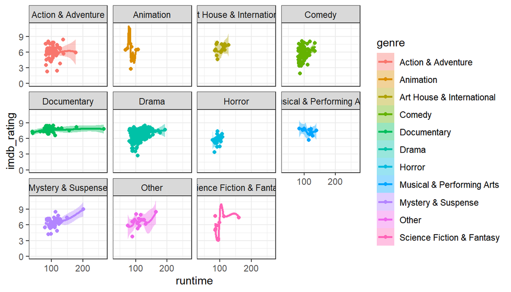

```r
m3 <- with(movies1, lm(imdb_rating ~ runtime + genre))
ggplot(movies1, aes(runtime, imdb_rating, fill = genre, col = genre)) +
 geom_point() +
  ylim(0, 11) +
  geom_smooth(model = m3) +
   facet_wrap(~ genre) +
    theme_bw()
```

## Part 4: Modeling

for the models we have two simple models of one variable, one with the genre and another model with the runtime and finally compare the models with a full model with both factors by its r square

```r
m1 <- lm(imdb_rating ~ genre, movies1)
m2 <- lm(imdb_rating ~ runtime, movies1)
m3 <- lm(imdb_rating ~ runtime + genre, movies1)
summary(m1)
```

```
##
## Call:
## lm(formula = imdb_rating ~ genre, data = movies1)
##
## Residuals:
##     Min      1Q  Median      3Q     Max
## -3.9734 -0.4734  0.0552  0.6234  2.5203
##
## Coefficients:
##                                Estimate Std. Error t value Pr(>|t|)
## (Intercept)                     5.97077    0.11913  50.120  < 2e-16 ***
## genreAnimation                 -0.07077    0.34160  -0.207  0.83594
## genreArt House & International  0.64352    0.28299   2.274  0.02330 *
## genreComedy                    -0.22594    0.15746  -1.435  0.15181
## genreDocumentary                1.67731    0.17869   9.386  < 2e-16 ***
## genreDrama                      0.70267    0.13121   5.355 1.19e-07 ***
## genreHorror                    -0.20990    0.23302  -0.901  0.36805
## genreMusical & Performing Arts  1.32923    0.30177   4.405 1.24e-05 ***
## genreMystery & Suspense         0.50889    0.17270   2.947  0.00333 **
## genreOther                      0.66048    0.26804   2.464  0.01400 *
## genreScience Fiction & Fantasy -0.21521    0.34160  -0.630  0.52890
## ---
## Signif. codes:  0 '***' 0.001 '**' 0.01 '*' 0.05 '.' 0.1 ' ' 1
##
## Residual standard error: 0.9605 on 640 degrees of freedom
## Multiple R-squared:  0.2281, Adjusted R-squared:  0.216
## F-statistic: 18.91 on 10 and 640 DF,  p-value: < 2.2e-16
```

```r
summary(m2)
```

```
##
## Call:
## lm(formula = imdb_rating ~ runtime, data = movies1)
##
## Residuals:
##     Min      1Q  Median      3Q     Max
## -4.3099 -0.5791  0.0714  0.7572  2.2500
##
## Coefficients:
##             Estimate Std. Error t value Pr(>|t|)
## (Intercept) 4.907873   0.227163  21.605  < 2e-16 ***
## runtime     0.014965   0.002111   7.088 3.56e-12 ***
## ---
## Signif. codes:  0 '***' 0.001 '**' 0.01 '*' 0.05 '.' 0.1 ' ' 1
##
## Residual standard error: 1.046 on 648 degrees of freedom
##   (1 observation deleted due to missingness)
## Multiple R-squared:  0.07195,    Adjusted R-squared:  0.07052
## F-statistic: 50.24 on 1 and 648 DF,  p-value: 3.564e-12
```

```r
summary(m3)
```

```
##
## Call:
## lm(formula = imdb_rating ~ runtime + genre, data = movies1)
##
## Residuals:
##     Min      1Q  Median      3Q     Max
## -3.9098 -0.5221  0.0525  0.5921  2.4074
##
## Coefficients:
##                                 Estimate Std. Error t value Pr(>|t|)
## (Intercept)                     4.596099   0.237685  19.337  < 2e-16 ***
## runtime                         0.013243   0.002002   6.616 7.82e-11 ***
## genreAnimation                  0.148778   0.332619   0.447   0.6548
## genreArt House & International  0.665463   0.274197   2.427   0.0155 *
## genreComedy                    -0.135125   0.153177  -0.882   0.3780
## genreDocumentary                1.777018   0.174684  10.173  < 2e-16 ***
## genreDrama                      0.609926   0.127896   4.769 2.30e-06 ***
## genreHorror                    -0.055354   0.226971  -0.244   0.8074
## genreMusical & Performing Arts  1.197458   0.293050   4.086 4.94e-05 ***
## genreMystery & Suspense         0.424538   0.167812   2.530   0.0117 *
## genreOther                      0.562645   0.260116   2.163   0.0309 *
## genreScience Fiction & Fantasy -0.178132   0.331007  -0.538   0.5907
## ---
## Signif. codes:  0 '***' 0.001 '**' 0.01 '*' 0.05 '.' 0.1 ' ' 1
##
## Residual standard error: 0.9305 on 638 degrees of freedom
##   (1 observation deleted due to missingness)
## Multiple R-squared:  0.2767, Adjusted R-squared:  0.2643
## F-statistic: 22.19 on 11 and 638 DF,  p-value: < 2.2e-16
```

the full model have the greatest adjusted r square

for the conclucion the popularity in in the IMDB raiting depends on the genre of the movie but documentaries genre in general have the highest reating on average, and the musicals with a long runtime will have less raiting

## Part 6: Conclusion

the genre and the runtime of a mive can help us to predict the IMDB raiting of a movie